# Changes in U.S. Incarcerated Populations after the 1994 Crime Bill

## Introduction

For my analysis of the Incarceration Trends data, I decided to focus on how differences in race and gender in the national incarcerated population were affected by the Violent Crime Control and Law Enforcement Act, or the 1994 Crime Bill, which was imposed by the Clinton Administration. My analysis file mainly focuses on differences in the amount of male vs. female inmates who were incarcerated as well as the proportions of total inmates before and after the 1994 Crime Bill. Additionally, I decided to calculate changes in the number of Black inmates before and after 1994. I believe that an analysis of this data can provide insights on information regarding the differences between the incarceration of People of Color compared to caucasian populations. Furthermore, my interest in the effects of the War on Drugs and War on Crime motivated me to look at incarceration rates specifically from this time period.

## Summary Information

My summary information consists of the different values between black and white incarcerated individuals. Since I am focusing on the analysis of increases in inmate population totals after the 1994 Crime Bill, I thought it would be interesting to calculate the average amount of individuals by both gender and race after 1994. I learned that the average amount of female inmates after 1994 was 46,688 women while the average amount of men was 46,179. Additionally, I calculated the proportion of total inmates from 1993 compared to 1995 which came out to be .976 demonstrating that there was about a .03 increase in the inmate population over the two years after the crime bill was introduced. Finally, I calculated the difference between the highest number of inmates that existed before 1994 and after 1994 which came out to be 9,100,159 before 1994 and 10,120,540 inmates after. I calculated the total difference between these totals which came out to be 1,020,381 people.

## Trends Over Time Chart

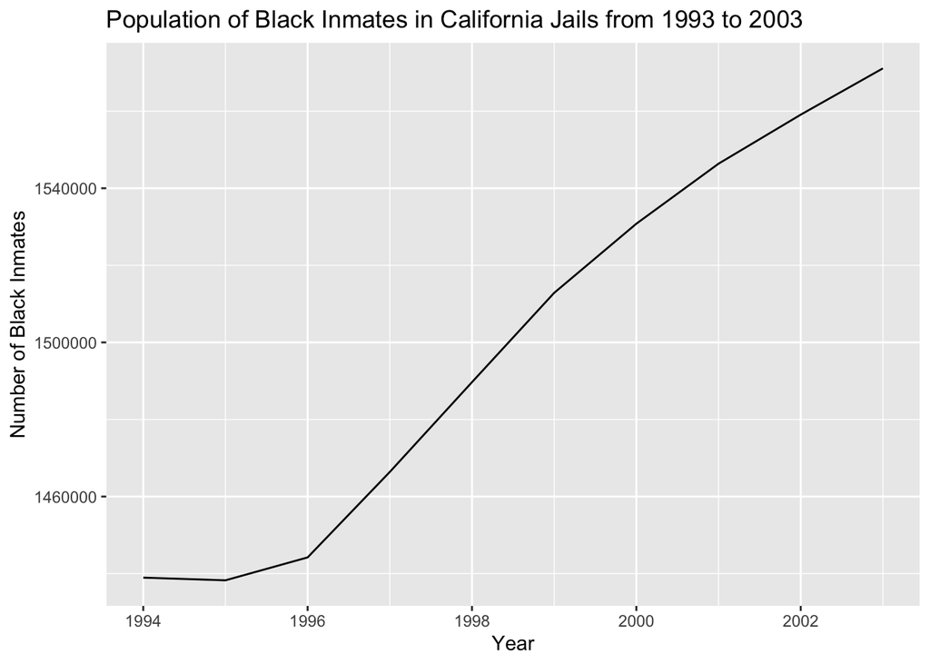

## Variable Comparison Chart

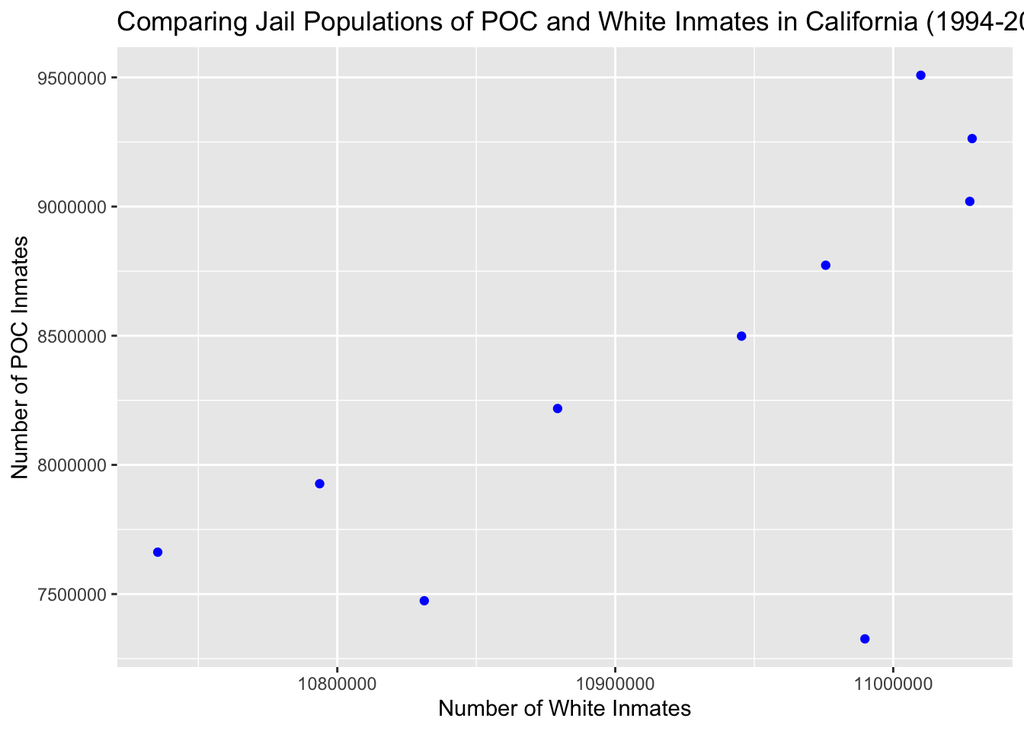

This chart compares the amount of people of color inmates to white inmates in California prisons after 1994. While there appears to be more white inmates than POC, the amount of POC inmates to white inmates should be expected to be proportional to the racial demographics of the state. This data shows that the amount of POC who are incarcerated compared to white people increased over the years and can be analyzed by taking into account that caucasian/non-POC people make up about 60% of the CA population while Black, Latinx, and Native communities make up about 25% (subtracting the 15% of Asian people that make up the CA racial demographics because they are not accounted for in the Incarceration dataset). As the years progress, POC appear to make up more than 25% of the total jail population demographic demonstrating disparities in incarceration rates for POC vs white inmates.

## Map

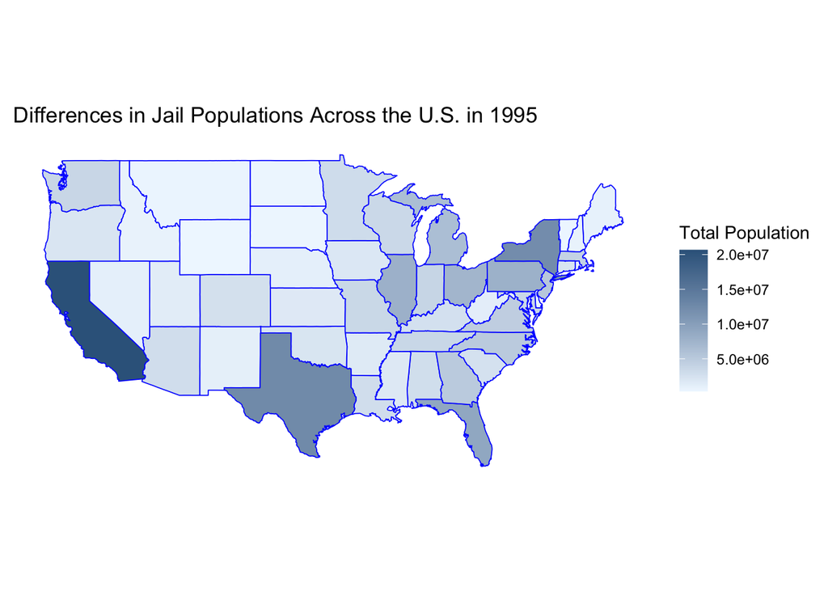

This map shows the differences in the total inmate populations in each state in 1995. I included this chart in order to see the differences in all of the states’ incarcerated populations as a result of the 1994 Crime Bill in order to see which states had the highest populations as compared to others. I think that when you look at the differences in incarcerated populations, it helps to take into account the specificity of the laws that they may have in each state when it comes to laws related to the prohibition of drugs and their history of racial discrimination. Through this chart, you can see the differences in populations as a result of legislation that has occurred both in the states and as a result of the War on Drugs and War on Crime. As you can see, the highest total population in 1995 appears to be in California. This makes sense when you think about how policing policies in California tended to be strict during the War on Drugs. Additionally, Texas and New York appear to be the second darkest states on the map demonstrating how high incarcerated populations tended to be in the highest populated states as well as states with certain policies such as New York’s Stop-and-Frisk policies and the effects of racial discriminatory laws in the south.